# Insights for Loan Data from Prosper

#### Dataset Overview

This dataset inclues 113,937 loans with 81 variables on each loan, including loan amount, borrower rate (or interest rate), current loan status, borrower income, and many others.

#### Insights to be drawn:

- Factor(s) affect a loan’s outcome status (completed/dafaulted).
- Factor(s) affect the borrower’s APR.
- Differences between loans depending on how large the original loan amount was.

To draw the above insights, after wrangling the dataset, the new dataset contains 26,005 loans with variables: **Term, LoanStatus, BorrowerAPR, ProsperRating, ListingCategory, EmploymentStatus, DelinquenciesLast7Years, TotalProsperLoans, LoanOriginalAmount, LoanOriginationDate, Recommendations**.

## Insight #1: What factors affect a loan’s outcome status?

### Factor #1: Defaulted loans, in general, have higher borrower APR than completed ones.

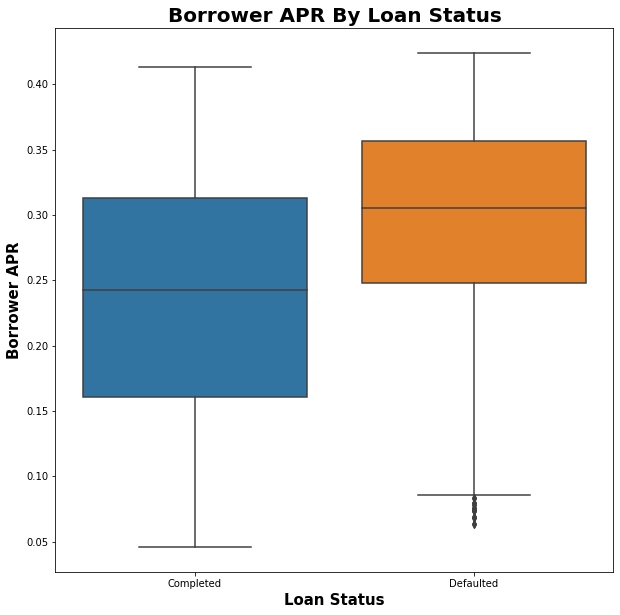

```python
# LoanStatus vs. BorrowerAPR
box_plot(x='LoanStatus', y='BorrowerAPR', title='Borrower APR By Loan Status', xlab='Loan Status', ylab='Borrower APR');
```

### Factor #2: Generally, the lower the Prosper rating, the higher number of defaulted loans is.

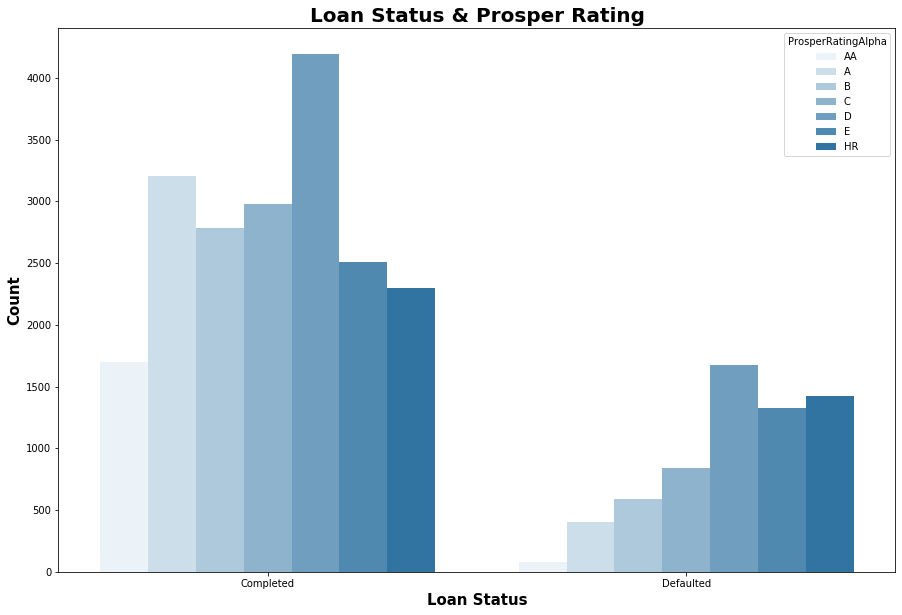

```python
# LoanStatus vs. ProsperRatingAlpha
count_plot(x='LoanStatus', hue='ProsperRatingAlpha', title='Loan Status & Prosper Rating', xlab='Loan Status');
```

### Factor #3: Borrowers in defaulted loans tend to have higher number of deliquencies in the last 7 years.

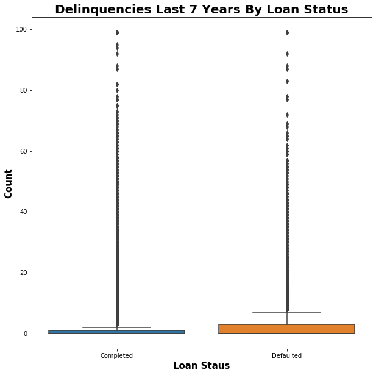

```python
# LoanStatus vs. DelinquenciesLast7Years
box_plot(x='LoanStatus', y='DelinquenciesLast7Years',
         title='Delinquencies Last 7 Years By Loan Status', xlab='Loan Staus', ylab='Count');
```

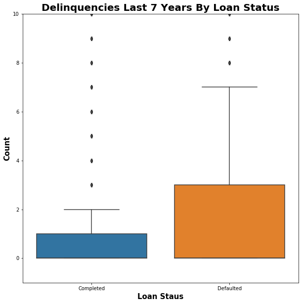

```python
# LoanStatus vs. DelinquenciesLast7Years
box_plot(x='LoanStatus', y='DelinquenciesLast7Years',
         title='Delinquencies Last 7 Years By Loan Status', xlab='Loan Staus', ylab='Count')
plt.ylim(-1, 10);
```

### Factor #4: Borrowers in defaulted loans tend to borrow less in terms of loan original amount.

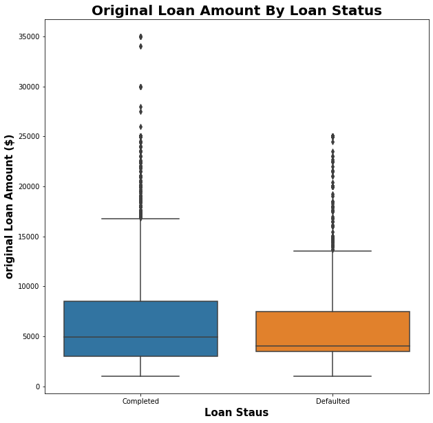

```python
# LoanStatus vs. LoanOriginalAmount
box_plot(x='LoanStatus', y='LoanOriginalAmount',
         title='Original Loan Amount By Loan Status', xlab='Loan Staus', ylab='original Loan Amount ($)');
```

## Insight #2: What affects the borrower’s APR?

### Factor #1: The higher the rating, the lower the APR is and vice versa.

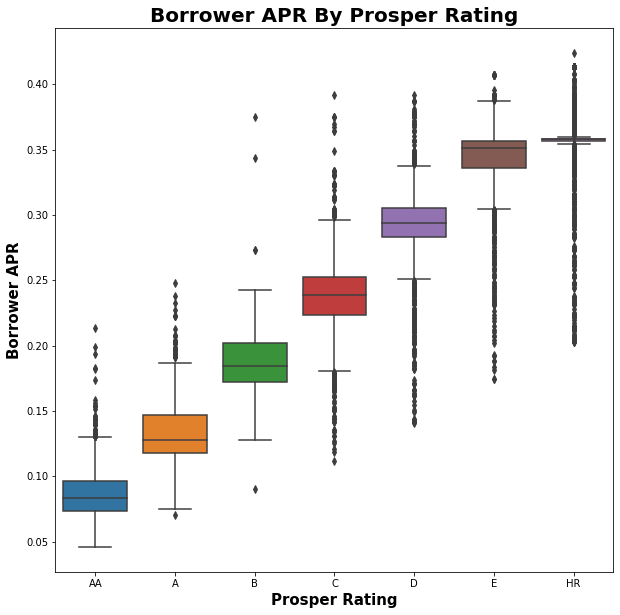

```python
# BorrowerAPR vs. ProsperRatingAlpha
box_plot(x='ProsperRatingAlpha', y='BorrowerAPR',
         title='Borrower APR By Prosper Rating', xlab='Prosper Rating', ylab='Borrower APR', order=ratings)
```

### Factor #2: Debt Consolidation and Home Improvement categories tend to have lower APR.

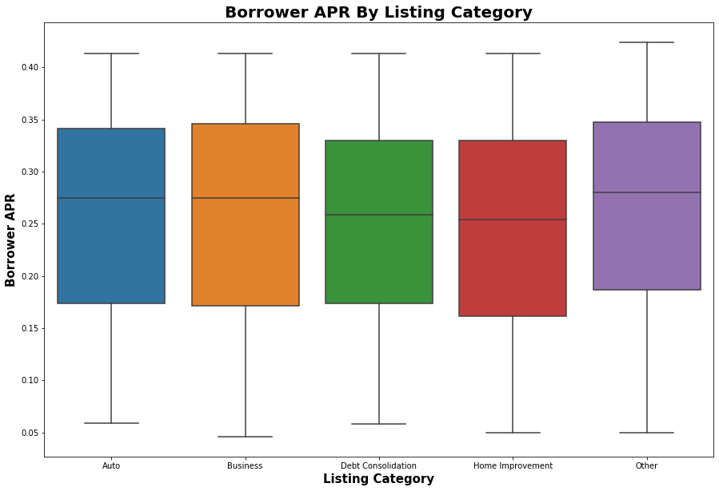

```python
# BorrowerAPR vs. ListingCategory
box_plot(x='ListingCategory', y='BorrowerAPR',
         title='Borrower APR By Listing Category', xlab='Listing Category', ylab='Borrower APR', figsize=(15, 10));
```

### Factor #3: Full-time, Part-time, Retired and Employed categories tend to have lower APR.

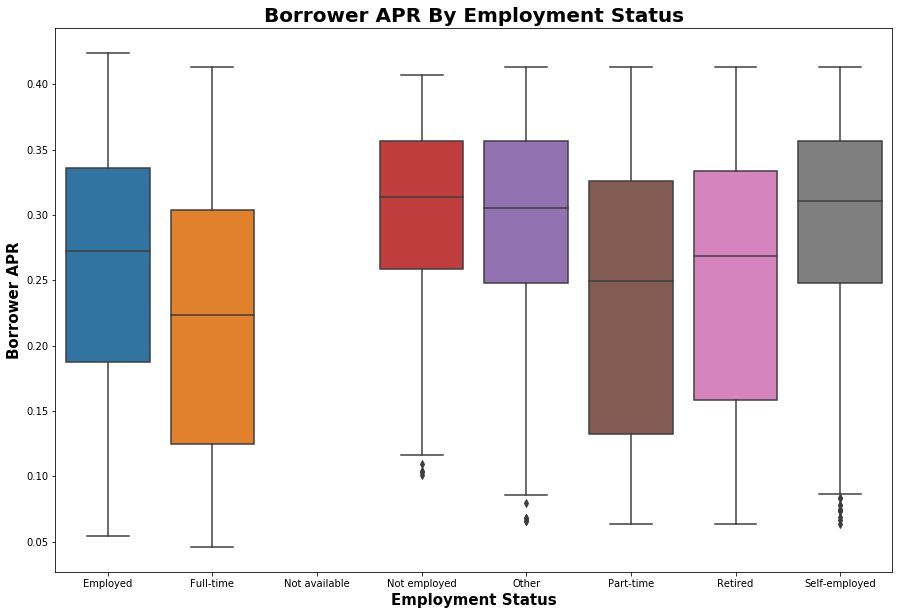

```python
# BorrowerAPR vs. EmploymentStatus
box_plot(x='EmploymentStatus', y='BorrowerAPR',
         title='Borrower APR By Employment Status', xlab='Employment Status', ylab='Borrower APR', figsize=(15, 10));
```

### Factor #4: The larger the original loan amount, the lower APR is and vice versa.

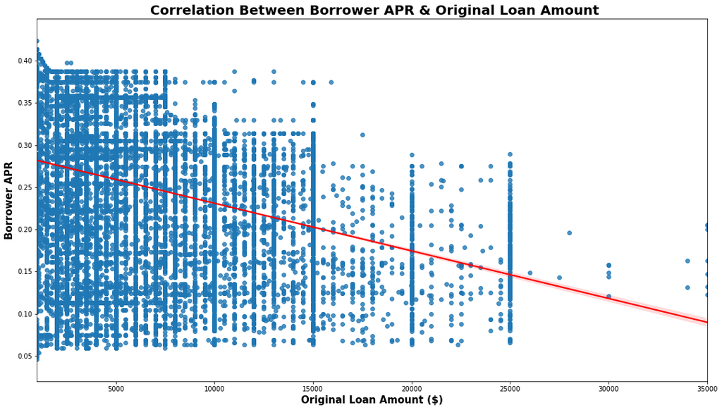

```python
# BorrowerAPR vs. LoanOriginalAmount
plt.figure(figsize=(18,10))
sns.regplot(data=loan_subset, x='LoanOriginalAmount', y='BorrowerAPR', line_kws={'color': 'red'})
plt.title(' Correlation Between Borrower APR & Original Loan Amount', fontsize=20, weight='bold')
plt.xlabel('Original Loan Amount ($)', fontsize=15, weight='bold')
plt.ylabel('Borrower APR', fontsize=15, weight='bold');
```

## Insight #3: Are there differences between loans depending on how large the original loan amount was?

### For a given original loan amount, borrower APR tends to be lower in completed loans than that in defaulted ones.

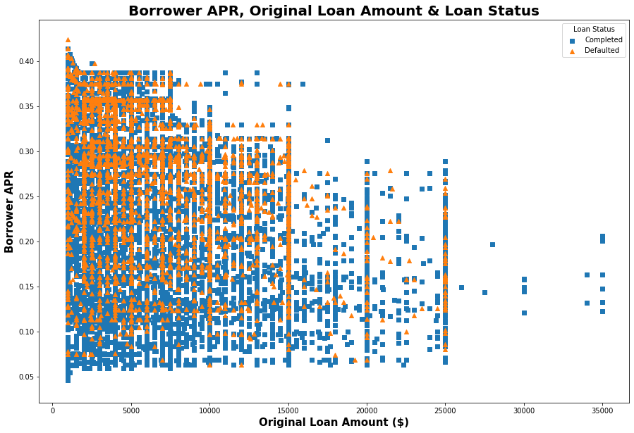

```python
# BorrowerAPR vs. LoanOriginalAmount vs. LoanStatus
markers = [['Completed', 's'], ['Defaulted', '^']]
plt.figure(figsize=(15,10))
for cat, marker in markers:
    loan_cat = loan_subset[loan_subset['LoanStatus']==cat]
    plt.scatter(data=loan_cat, x='LoanOriginalAmount', y='BorrowerAPR', marker=marker)
plt.xlabel('Original Loan Amount ($)', fontsize=15, weight='bold')
plt.ylabel('Borrower APR', fontsize=15, weight='bold')
plt.title('Borrower APR, Original Loan Amount & Loan Status', fontsize=20, weight='bold')
plt.legend(['Completed', 'Defaulted'], title='Loan Status');
```

### Auto or Business categories tend to have higher risks in terms of original loan amount.

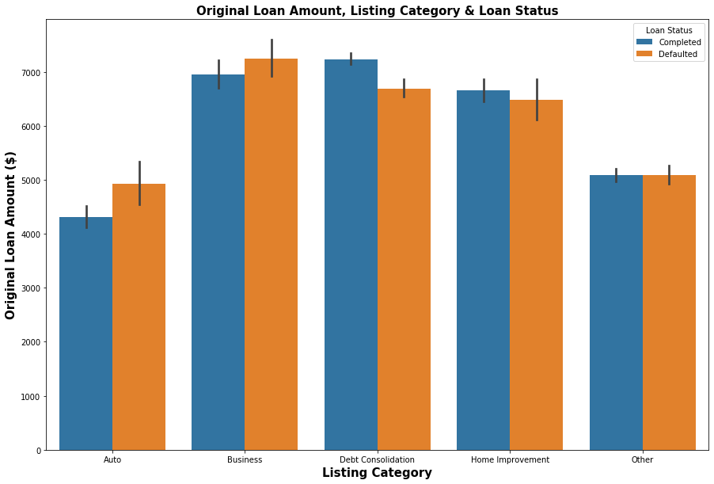

```python
# LoanOriginalAmount vs. ListingCategory vs. LoanStatus
plt.figure(figsize=(15,10))
sns.barplot(data=loan_subset, x='ListingCategory', y='LoanOriginalAmount', hue='LoanStatus')
plt.xlabel('Listing Category', fontsize=15, weight='bold')
plt.ylabel('Original Loan Amount ($)', fontsize=15, weight='bold')
plt.title('Original Loan Amount, Listing Category & Loan Status', fontsize=15, weight='bold')
plt.legend(title='Loan Status');
```